# Hypothesis Testing - Overall Physical Health

4/18/2020

Lealena Befikadu

## Introduction

The Behavioral Risk Factor Surveillance System (BRFSS) is the nation’s premier system of health-related telephone surveys that collect state data about U.S. residents regarding their health-related risk behaviors, chronic health conditions, and use of preventive services.

This report seeks to identify target populations for physical health interventions. In order to identify these target populations, we would like to perform statistical testing in order to determine whether or not the interventions should differ across different demographics. One demographic variable we are interested in looking into is sex.

The BRFSS includes a section on the Health-Related Quality of Life. In order to measure the “Number of Days Physical Health Not Good”, respondents were asked: *Now thinking about your physical health, which includes physical illness and injury, for how many days during the past 30 days was your physical health not good?* This question will be used as a proxy to measure overall physical health for survey respondents, where the higher the number of days indicated, the lower overall physical health. The following analysis seeks to determine whether the **Number of Days Physical Health Not Good is greater in males, compared to females.**

## Data Cleaning/Preparation

To prepare the analysis, I first called the libraries needed to conduct it. I, then, set my working directory to find the dataset and read it in. After this, I went through the dataset to clean and recoded the dataset to remove the values for the variable “Number of Days Physical Health Not Good” (PHYSHLTH) that were over 30 since after 30 the numbers were special values. Then, I created a new variable named “SEX2” that recoded the variable “SEX” to its non-numeric counterpart. After, I found the mean of PHYSHLTH to find the average number of days physical health was not good which was 15 days. Lastly, I found the count of males and females in the data which was 996 for males and 2,264 for females. Performing these functions all helped give information relating to the topic in question.

```r
#call libraries
library(ggplot2)
library(dplyr)
library(tidyr)
library(tidyverse)


#set working directory
setwd("/Users/lealenabefikadu/Downloads")
#read file
BRFSS <- read.csv("BRFSS.csv", header = TRUE)
#remove PHYSHLTH variable value above 30
df <- mutate(BRFSS, PHYSHLTH = ifelse(PHYSHLTH > 30, NA, PHYSHLTH))
#recode SEX to SEX2
df$SEX2 <- ifelse(df$SEX==1, "Male", ifelse(df$SEX==2, "Female", NA))
#mean of PHYSHLTH after recode
mean(df$PHYSHLTH, na.rm = TRUE)
```

```
## [1] 15.04811
```

```r
#count of males and females
plyr::count(df$SEX2)
```

```
##        x freq
## 1 Female 2264
## 2   Male  996
```

# Data Visualization

To visualize the situation, I created a boxplot that shows the difference in spread/central tendency of the “Number of Days Physical Health Not Good” variable, by SEX2. The median of “Number of Days Physical Health Not Good” in males was around 14 days and 12 days for females, but the spread of the data was the same, so there was only a slight difference.

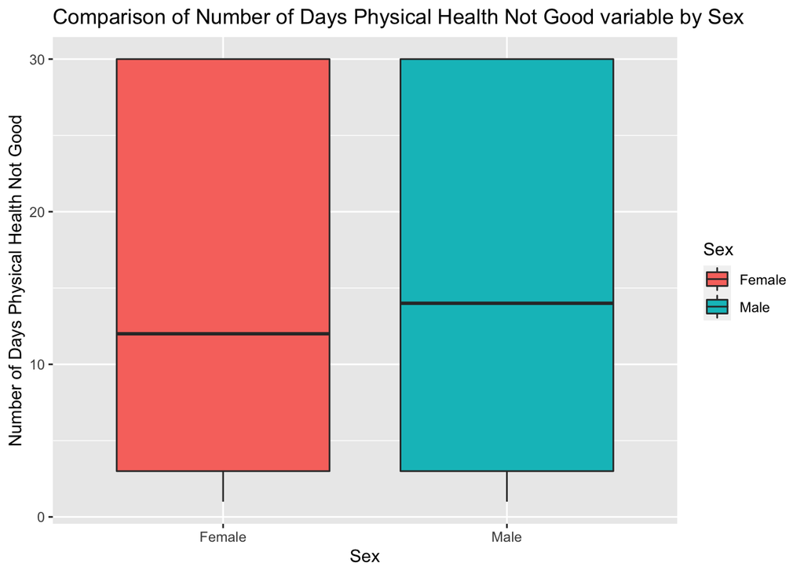

## Hypothesis Test

**Null Hypothesis** = The “Number of Days Physical Health Not Good” in males compared to females is the same

**Alternative Hypothesis** = The “Number of Days Physical Health Not Good” is greater in males compared to females

**Alpha** = 0.05

**Type of test (upper, lower, two-sided)** = Upper-tailed

**P-Value** = 0.1725

```r
#run hypothesis test
with(df, wilcox.test(x=PHYSHLTH[SEX2=="Male"],
                          y=PHYSHLTH[SEX2=="Female"],
                          alternative = "greater"))
```

```
##
##  Wilcoxon rank sum test with continuity correction
##
## data:  PHYSHLTH[SEX2 == "Male"] and PHYSHLTH[SEX2 == "Female"]
## W = 165767, p-value = 0.1725
## alternative hypothesis: true location shift is greater than 0
```